# Project2

Gaussian random field with application of INLA

Florian Beiser, Yaolin Ge

# Part I Multivariate normal distribution

Let $\boldsymbol{x} = (x_1, \dots, x_n), n = 100$ be multivariate normal distributed with $E(x_i) = 0, Var(x_i) = 1$, and $Corr(x_i, x_j) = e^{-0.1|i - j|}$

1. Compute and image the covariance matrix $\boldsymbol{\Sigma}$ of $\boldsymbol{x}$
2. Find the lower Cholesky factor $\boldsymbol{L}$, such that $\boldsymbol{L}\boldsymbol{L}^T = \boldsymbol{\Sigma}$, of this covariance matrix, and image.
3. Sample $\boldsymbol{x} = \boldsymbol{Lz}$, where $\boldsymbol{z}$ is a length n random vector of independent standard normal variables. Plot the sample.
4. Find the precision matrix $\boldsymbol{Q}$ of the covariance matrix, and compute the lower Cholesky factor $\boldsymbol{L}_Q$, such that $\boldsymbol{L}_Q\boldsymbol{L}_Q^T = \boldsymbol{Q}$, of this matrix. Image these matrices and compare them to the images obtained in a) and b)
5. Sample $\boldsymbol{x}$ by solving $\boldsymbol{L}_Q^T\boldsymbol{x} = \boldsymbol{z}$, where $\boldsymbol{z}$ is a length n random vector of independen standard normal variables. Plot the sample.
6. Permute the ordering of variables in $\boldsymbol{x}$, and redo the exercises.

## Solution to Part I

### a)

Given that $\boldsymbol{\Sigma} = e^{-0.1|i - j|}$. The covariance matrix can be expressed as follows:
$$\begin{equation*}
\Sigma = \begin{pmatrix}
1 & e^{- 0.1 h_{12}} &\dots & e^{- 0.1 h_{1n}} \\
e^{- 0.1 h_{21}} & 1 & \dots & e^{- 0.1 h_{2n}} \\
\vdots & \vdots & \ddots & \vdots \\
e^{- 0.1 h_{n1}} & e^{- 0.1 h_{n2}} & \dots & 1
\end{pmatrix}
\end{equation*}$$

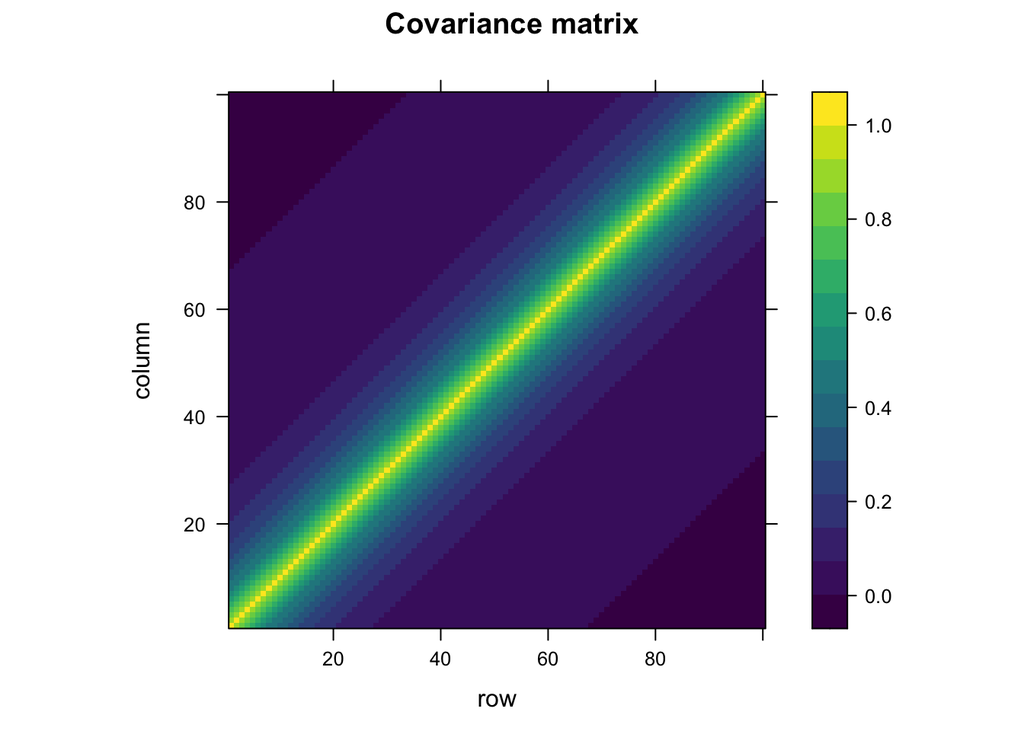

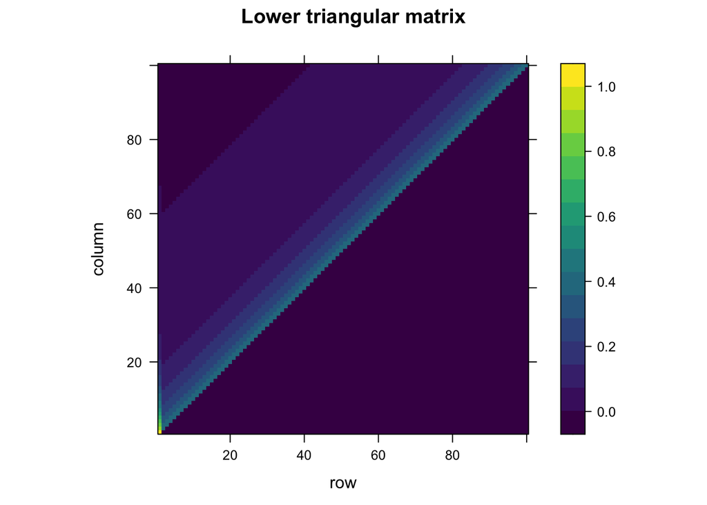

### c)

Sample using $\boldsymbol{x} = \boldsymbol{L}\boldsymbol{z}$ transforms the zero-mean, standard normal random variales to the random variables with the desired covariance matrix.

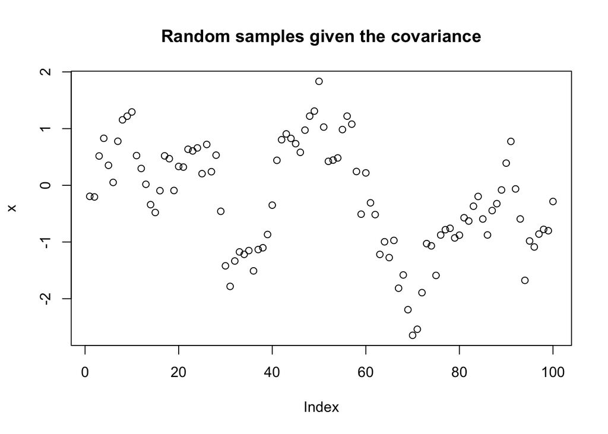

### d)

The precision matrix $\boldsymbol{Q}$ is the inverse of the covariance matrix $\boldsymbol{\Sigma}$, it is computed using `Q = solve(Sigma)` in R. The three matrices are thereby depicted as follows. Since the covariance matrix is not singular, given that the it belongs to the Matern family, thus it is analytically guaranteed to have positive definite property. Therefore, both precision matrix and the lower triangular precision matrix exist.

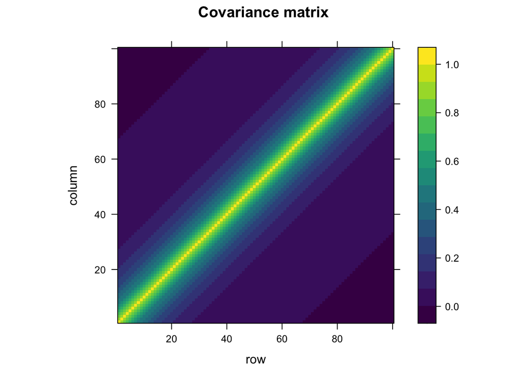

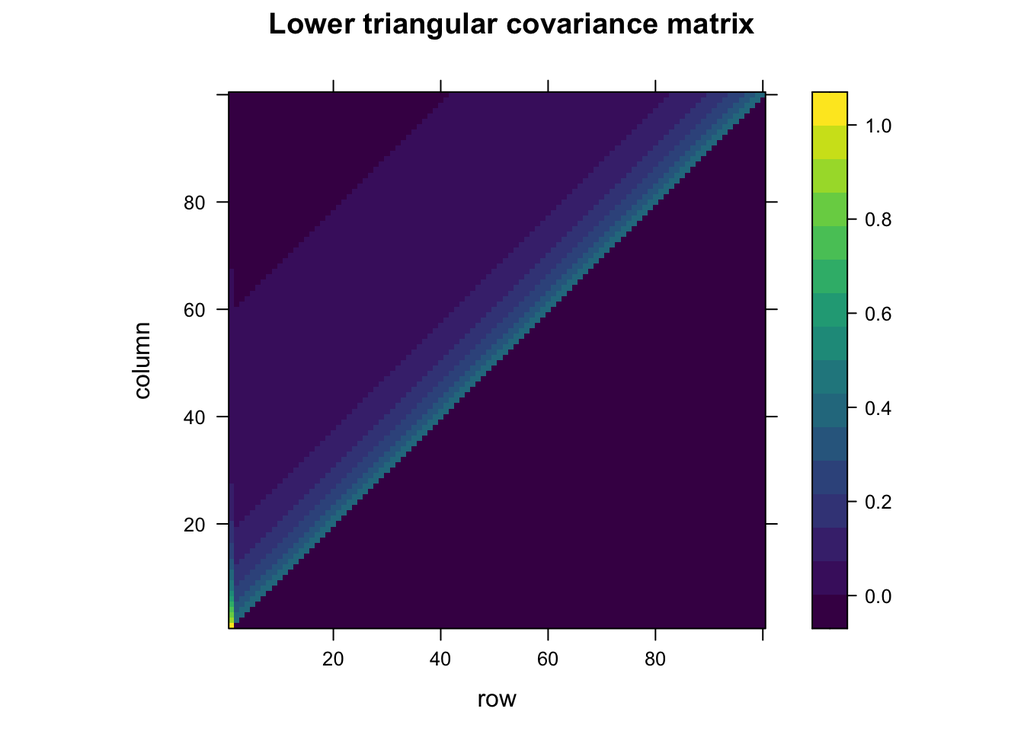

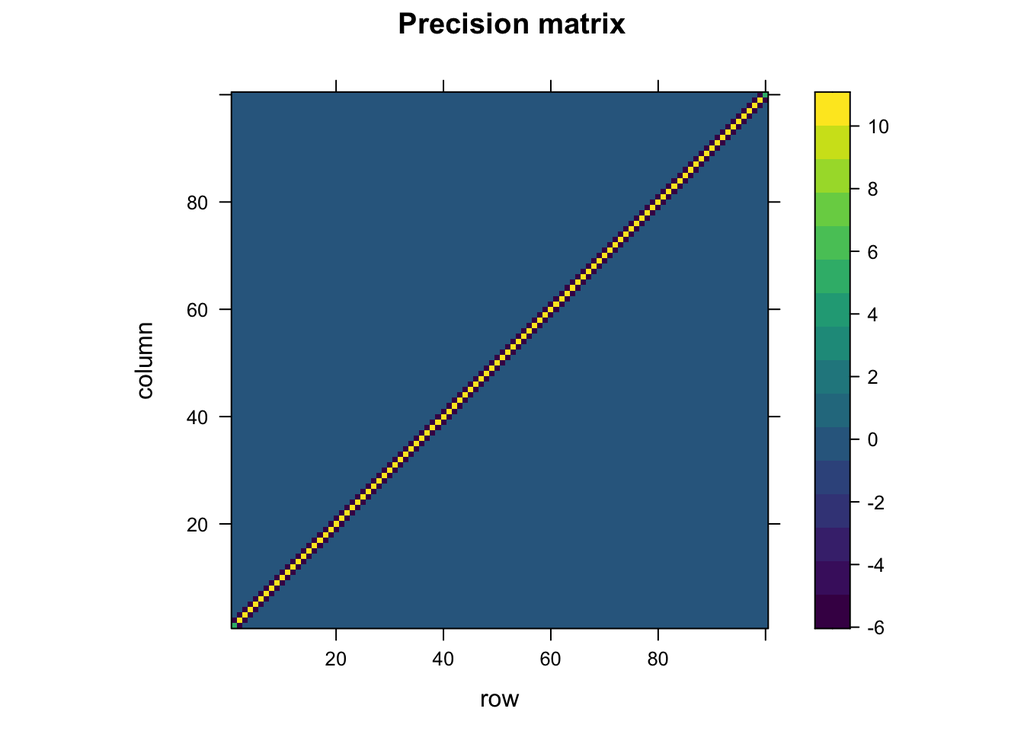

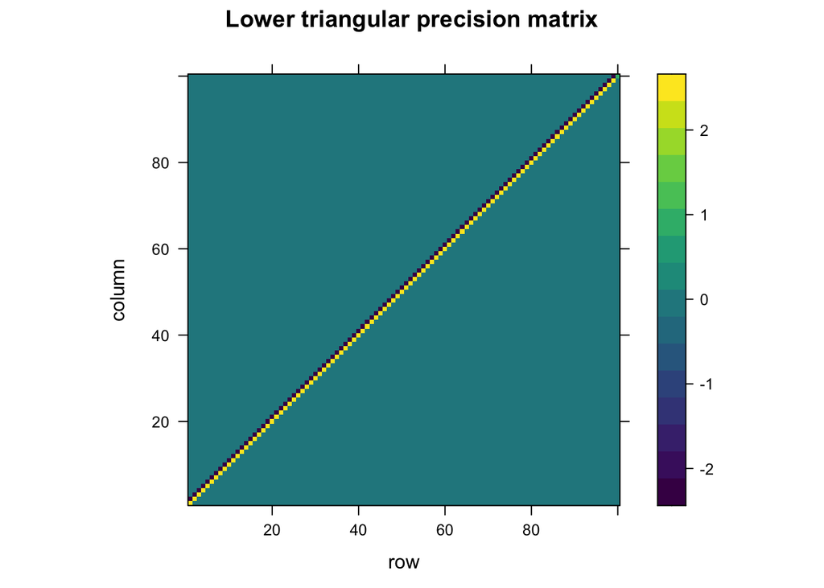

### e)

Similarly, the expected random samples can be generated using the inversion of the above formula, thus $\boldsymbol{L}_Q^T\boldsymbol{x} = \boldsymbol{z}$

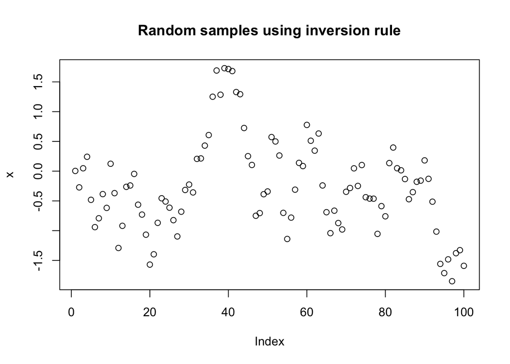

### f)

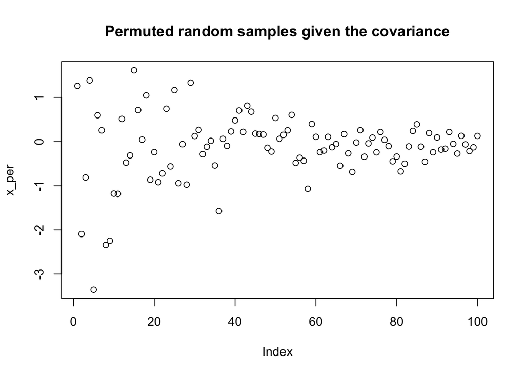

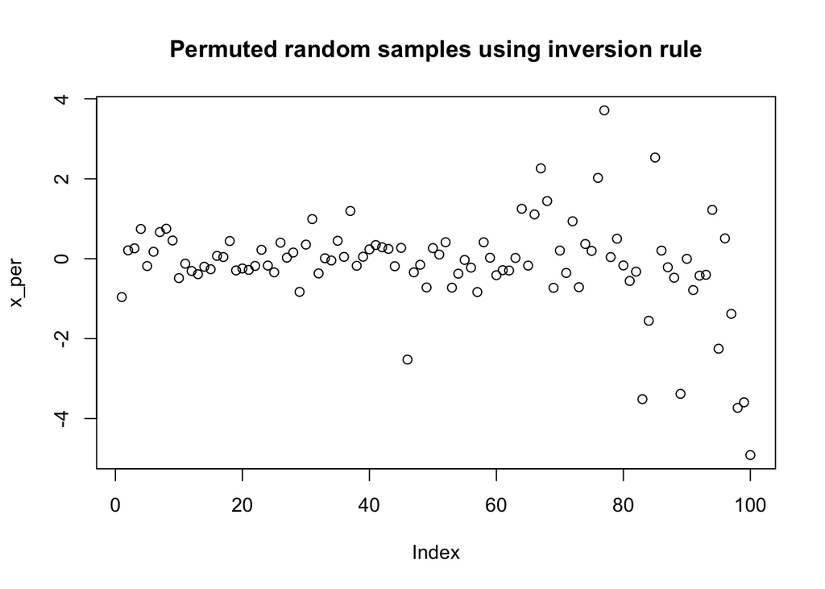

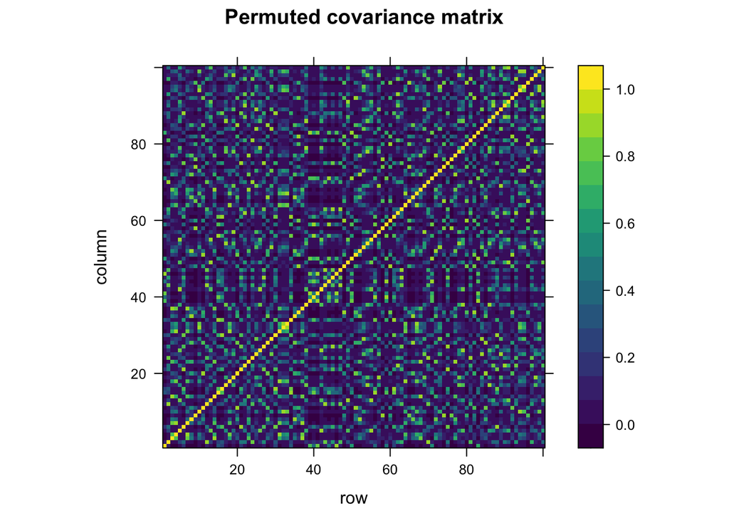

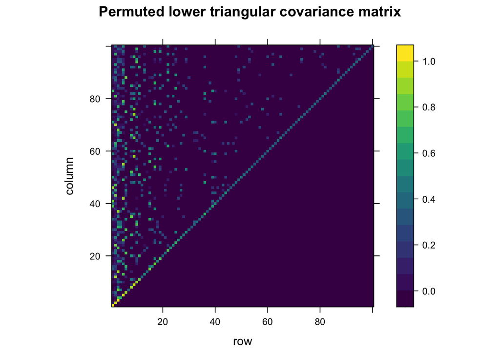

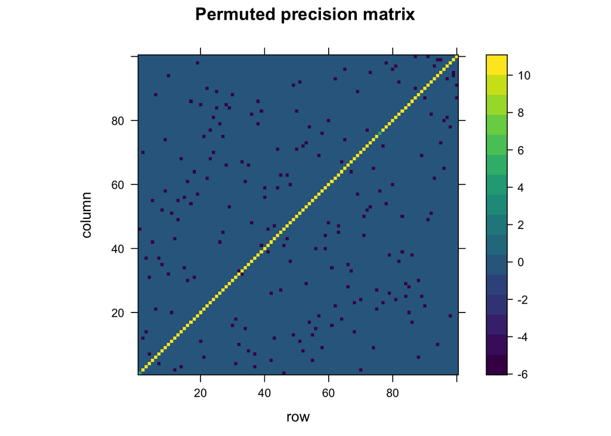

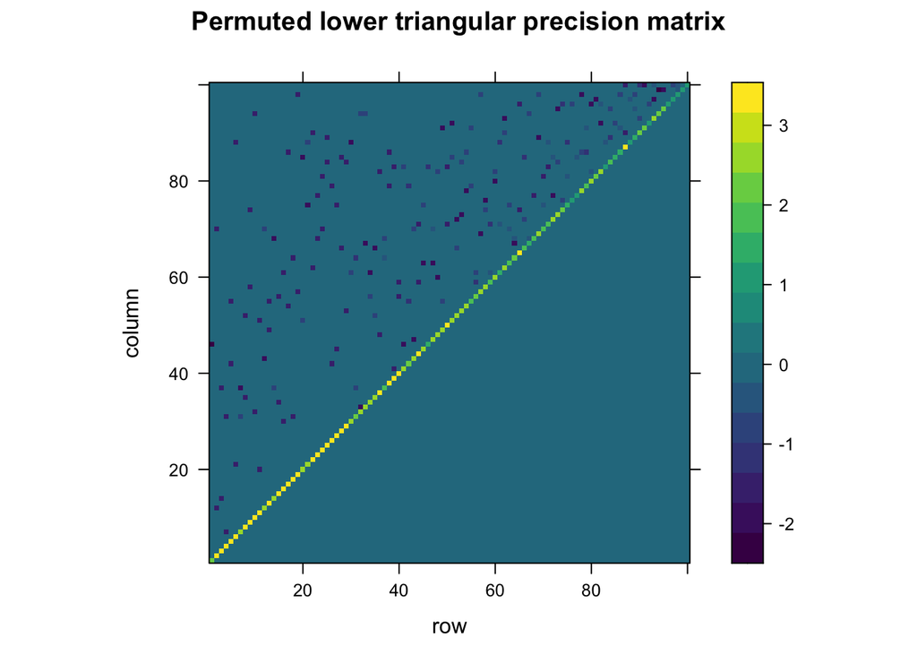